# CBB simulations

Rune Haubo B Christensen @ Christensen Statistics

18 May 2018

```r
library(sensR)
library(ggplot2)
namedList <- function(...) {
    setNames(list(...), nm=sapply(as.list(match.call()), deparse)[-1])
}
rbindall <- function(...) do.call(rbind, ...)
```

```r
n <- 12 # no. assessors
k <- 4  # no. replications per assessor
nsim <- 500
p0 <- 1/3
set.seed(123)
data_list <- lapply(1:nsim, function(i) {
  mu <- runif(1)
  gamma <- runif(1)
  a <- mu * (1/gamma - 1)
  b <- (1 - mu) * (1/gamma - 1)
  sim_pd <- rbeta(n, a, b)
  sim_pc <- p0 + (1-p0) * sim_pd
  y <- rbinom(n = rep(1, n), size = rep(k, n), prob = sim_pc)
  response <- cbind(y, rep(k, n))
  namedList(mu, gamma, sim_pd, sim_pc, y, response)
})
```

Fit `betabin` and `cbb` models:

```r
betabin_fits <- lapply(data_list, function(x)
  try(betabin(x$response, method = "threeAFC",
              corrected = TRUE, vcov = FALSE), silent = TRUE))
cbb_fits <- lapply(data_list, function(x)
  try(optimcbb(x$y, k = k, p0 = 1/3), silent=TRUE))
```

```
## A convergence problem or an error occurred.
##
## Changing initial values to randomly generated: (0.770288503783473, 0.315004099650742)
```

```r
# str(betabin_fits[[1]])
any(sapply(betabin_fits, class) == "try-error")
```

```
## [1] FALSE
```

```r
conv_betabin <- sapply(betabin_fits, "[[", "convergence")

# str(cbb_fits[[1]])
any(sapply(cbb_fits, class) == "try-error")
```

```
## [1] FALSE
```

```r
conv_cbb <- sapply(cbb_fits, "[[", "conv")

# convergence indicator:
conv_fail <- rep("none", nsim)
conv_fail[conv_betabin > 0] <- "betabin"
conv_fail[!conv_cbb] <- "cbb"
conv_fail[conv_betabin > 0 %% !conv_cbb] <- "both"
```

Compare parameter estimates:

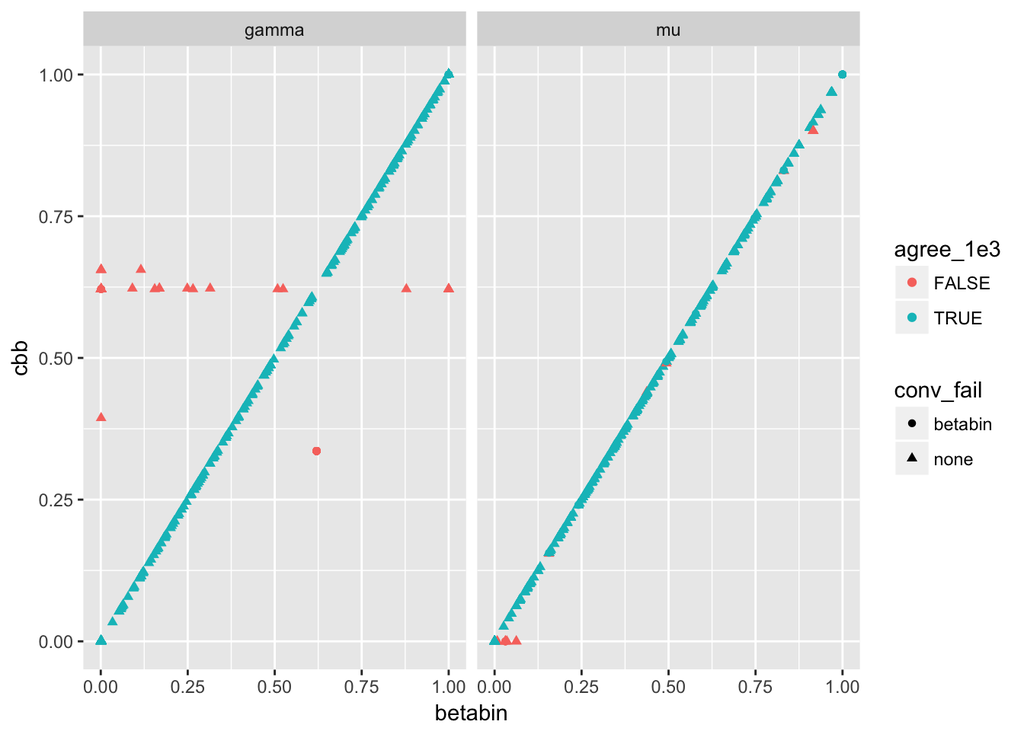

```r
parmat_betabin <- rbindall(lapply(betabin_fits, coef))
parmat_cbb <- rbindall(lapply(cbb_fits, function(x) unlist(x[c("mu", "gamma")])))

estimates <- data.frame(betabin=c(parmat_betabin),
                        cbb=c(parmat_cbb),
                        parameter=rep(c("mu", "gamma"), each=nrow(parmat_cbb)),
                        conv_fail=c(conv_fail, conv_fail))
estimates$agree_1e3 <- abs(estimates$betabin - estimates$cbb) <= 1e-3
ggplot(estimates, aes(betabin, cbb, color=agree_1e3, shape=conv_fail)) +
  geom_point() + facet_wrap(~parameter)
```

Color and shape of symbols indicate agreement of parameter estimates to a tolerance of `1e-3` and optimizer reported convergence indicator respectively.

Note that `betabin` and `optimcbb` use different optimizers and it is the convergence code from these optimizers which is shown here. The optimizer in `betabin` (`L-BFGS-B`) declares non-convergence more often than the one in `optimcbb` (`Nelder-Mead`) which on these 500 cases never declares anything but successful convergence. It seems that `L-BFGS-B` may be a bit over-cautious given the number of cases where the parameter estimates from the two optimizers agree, while `Nelder-Mead` declares convergence even when it (presumably) fails to converge (which may *also* be true for `L-BFGS-B`).

Note the problematic situation around $\gamma = 0.62$ for the `optimcbb` fits. It is unclear if `optimcbb` or `betabin` has a problem here.

Compare likelihoods:

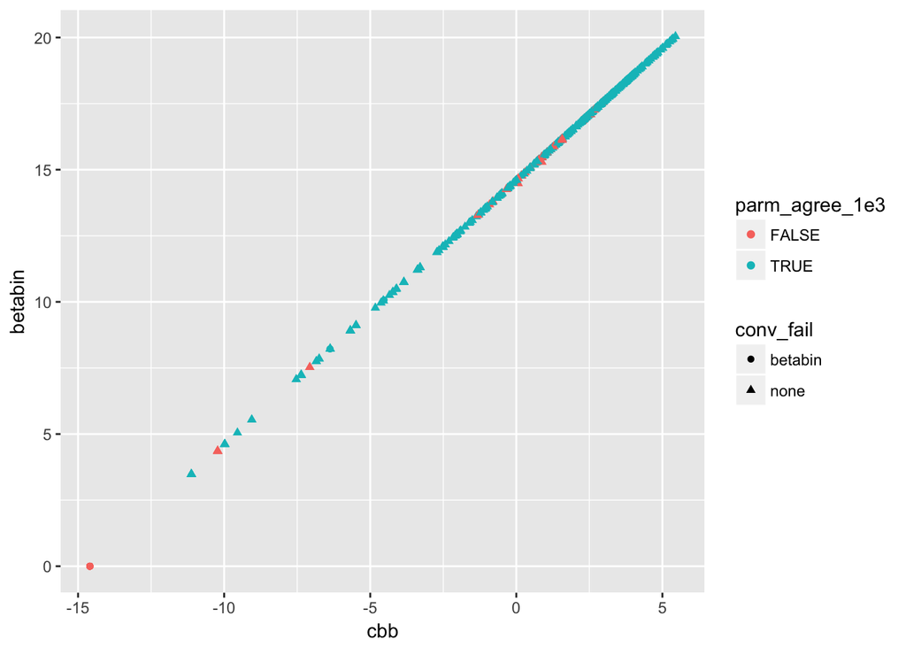

```r
cbb_nll <- sapply(cbb_fits, "[[", "neg.loglik")
betabin_nll <- -sapply(betabin_fits, logLik)
parm_agree_1e3 <- sapply(1:nrow(parmat_cbb), function(i)
  all(abs(parmat_betabin[i, ] - parmat_cbb[i, ]) < 1e-3))

nlldf <- data.frame(cbb=cbb_nll, betabin=betabin_nll,
                    parm_agree_1e3,
                    conv_fail)
ggplot(nlldf, aes(cbb, betabin, color=parm_agree_1e3, shape=conv_fail)) +
  geom_point()
```

The two implementations agree on the calculation of the log-likelihood apart from a constant term. Also note that the log-likelihoods agree even in cases when the parameter estimates do not - this indicates that the problem is optimizing the likelihood function when it is very flat wrt. the parameters.

Look at the *true* parameter values (i.e. the values from which the parameters of the beta-distribution for $p_d$ are drawn):

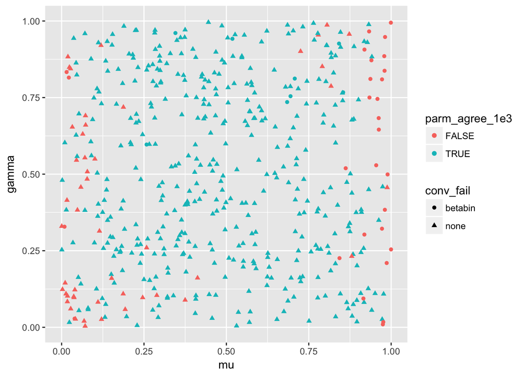

```r
# dev.new()
mugamma <- as.data.frame(rbindall(lapply(data_list, function(l)
  unlist(l[c("mu", "gamma")]))))
mugamma$parm_agree_1e3 <- parm_agree_1e3
mugamma$conv_fail <- conv_fail
# str(mugamma)
ggplot(mugamma, aes(x=mu, y=gamma, color=parm_agree_1e3, shape=conv_fail)) +
  geom_point() + xlim(0,1) + ylim(0,1)
```

This indicates that `betabin` often declares non-convergence for $\mu$ near 1 and that disagreement in parameter estimates is often seen for $\mu$ near its boundaries at 0 and 1, but also when both $\gamma$ and $\mu$ are small.

Surprisingly $\gamma$ values near 0 and 1 are no problem unless $\mu$ is also near 0 or 1.

Tabulate parameter agreement by convergence status:

```r
addmargins(tab <- with(mugamma, table(parm_agree_1e3, conv_fail)))
```

```
##               conv_fail
## parm_agree_1e3 betabin none Sum
##          FALSE      29   49  78
##          TRUE        8  414 422
##          Sum        37  463 500
```

Same in percent:

```r
addmargins(prop.table(tab)*100)
```

```
##               conv_fail
## parm_agree_1e3 betabin  none   Sum
##          FALSE     5.8   9.8  15.6
##          TRUE      1.6  82.8  84.4
##          Sum       7.4  92.6 100.0
```